# Marketing Science with R

2019/5/25

## 自己紹介

- 労働者階級2年目
  - マーケティング系調査屋さんのアナリスト
    - **兼**アナリスト候補のヘッドハンター
    - **兼**部署内作業環境改善係
    - **兼**広報担当
- 最近の出来事
  - 転職しないことにした
    - キャリアなんもわからん問題でバズってしまった
    - なお今もなんもわからん模様
  - OSをUbuntuに変えたらMSOffice使えないじゃない……

## 宣伝

- Statistician-jaのDiscordをつくりました
  - 「数理統計学」をやっていくサーバ
    - 「10人くらいかなあ」
- 今では300人超えてきた
  - FF外からいっぱい来た
  - 界隈のドンからも反響があった

## 宣伝

[figure not shown]

## 嬉しい悲鳴

- PythonとかRとかではなく「数理統計」のお勉強をやろう
  - `lm(y~., data = dat)`の裏のロジックをつかもう
  - 理論は廃れないのでみんなで理解しよう
- 目標は統計検定1級に合格することなど
- https://discord.gg/Nq75Smpにアクセス！
  - Meetupとかも構想中です。
  - 運営の仕方とか教えてほしい

## 今日のお話

- 「Rって非Tech系企業でどう使われているんですか？」なお話
  - R: エンジニアじゃない人も割と使ってる
  - 故に「バージョン管理」とかよく分かってないことも……
    - 最近社内で[Uribo先生の資料](https://speakerdeck.com/s_uryu/rstudio-for-team)を紹介しました
- マーケティング・リサーチ業界でのお話
  - 偏見があります
- R要素は？
  - これがRmarkdownでできている
  - それで十分じゃないか……？
  - ioslideの無骨さいい……

## 「マーケティング」って何？

## 実際に聞いてみたい

- Q.「マーケティングってなんだと思いますか？」

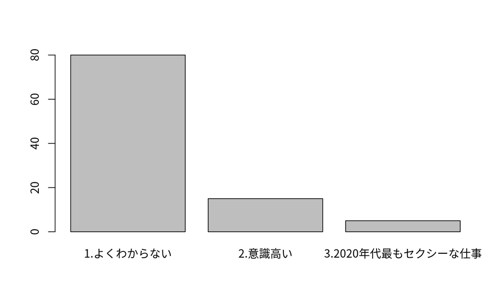

## きぬいともよくわかんない

- 「ドリルを買う人は、ドリルがほしいんじゃなくて、穴がほしいんだよ」

[figure not shown]

- 新人だったころのきぬいと「胡散臭い」

## 「マーケティング」のよくわからなさ

- どうなったら「うまくいった」と言えるのかが**よくわからない**
  - 測定指標(KGIだのKPIだの)の定義がTPOによって異なる
    - あるいは大きく定義変更がなされる
- 指標の測定方法も**よくわからない**
  - この辺は実験計画法とか結構大事
  - でも**よくわからない**まま実行しがち
- データ活用法のよくわからなさ
  - 大体の日本企業はデータはある
    - 「何がわかれば利益につながるのか」**よくわからない**
  - 選択肢が多すぎると逆に選べない
  - どんなデータがあると何がわかるのか**よくわからない**

なんもわからん

[figure not shown]

## データは使いたい

## でもデータ活用は進まない

Just You Know Why

[figure not shown]

- 知らない人は「panda チーズ」でググって

## 理由1. KKD信仰

## KKD（経験・勘・度胸）

- 実際その道のベテランのK・Kは馬鹿にはできない(くやしい)
  - 実際Dなしに決定はできない(それはそう)
- データ分析の価値もKKDに合うかどうかで決まるところもある
  - 「合っているかどうか」を評価する基準が定義できない
  - 結果「経験」「勘」に頼らざるを得ない

## 理由2. Excel信仰

## 「Excelでなんでもできるじゃん」

- **「なんでもはできないわよ、できることだけ」**
  - Excelでの手計算のミスが業務の8割を占めた2018年度
  - 誰もやりたくてやらかすわけじゃない
- Excelでできないこと=「不可能」
  - 「Excelじゃどうしようもない大規模なデータなんです」
    - **20万行** × 3列
- Excelで回帰分析やパラメータの調整
  - 実際できる
  - 計算プロセスも見やすいね
- 「もう全部Excelでよくない？」

## その結果

- 【きぬいと編集】案件結果_上司確認_ver2_2019xxxx.xls

[figure not shown]

## 全部Excelでよくない？→よくない！

- バージョン管理が煩雑になる
  - 追加で見たい指標がどんどん増えてサグラダファミリア.xlsx
- 作業工程が属人化する
  - Excelのプロフェッショナリティで給与が決まりがち
- この2つをどうにかしたくない？

## 非Tech系データ分析

## 仕事の8割が記述統計

- `table`や`ggplot`で解決する問題が大半
  - そもそも誰もデータを見ていない
    - 故にKPIもKGIもよくわからない
  - 分布や単純なクロス集計だけでも発見があることが多い
    - ここで初めてどの指標の評価をするかも判断できる
- 予測や分類はこの次のステップ
  - データをちゃんと見せよう
  - **魅せる**ことすら時期尚早

## 非Tech的Rの記述

- 記述統計レベルで解決する場合が多い
  - と言いつつそこそこデータ量が多い
- ある業務でのきぬいと

```r
  dat <- datA %>%
    dplyr::group_by(ID, date) %>%
    dplyr::summarise(count = n()) %>%
    tidyr::spread(.,key = date, value = count) %>%
    dplyr::mutate_if(is.numeric, funs(replace(.,is.na(.),0))) %>%
    dplyr::ungroup()
```

- これでログ形式のデータからIDと時系列別に何かをカウントして横展開とかする
  - そして平均とか行和列和とか見ながらグラフ出すとか

## 出力

```r
dat[,1:10] %>% head
```

```
## # A tibble: 6 x 10
##      ID `100` `101` `102` `103` `104` `105` `106` `107` `108`
##   <int> <dbl> <dbl> <dbl> <dbl> <dbl> <dbl> <dbl> <dbl> <dbl>
## 1     1     1     0     0     0     0     0     0     0     0
## 2     2     0     1     0     0     0     0     0     0     0
## 3     3     0     0     1     0     0     0     0     0     0
## 4     4     0     0     0     1     0     0     0     0     0
## 5     5     0     0     0     0     1     0     0     0     0
## 6     6     0     0     0     0     0     1     0     0     0
```

## つまり？

### 整 然 宇 宙 開 発 局

[figure not shown]

## 冗談抜きで

- `tidyverse`で既存業務がだいぶ改善した
  - 残業時間を大幅に減らしたらストレスが減った
  - 上司が助かっているかはわからない……助かっていると信じたい
- でかいExcelファイルを開くのに待つ必要性がだいぶ減った
- `ggplot2`やら`DiagrammeR`やらでの可視化で表を見やすくできる
- いいぞ

## お客様の声

- 「この動きは知らなかったなあ」
- 「ライバルと比べるとこうなっているのか」
- 「ここからこういうことできますか？」

## 結論

- Marketing Scienceは記述統計から入ろう
  - 回帰分析とか誰も知らない
  - よくあるご質問「切片は誤差ですか？」
- Statisticの語源に忠実にいこう
  - state/status「状態」の記述
  - **マーケティングで推定とかそんなの魔法っすよ。**

## 今後

- 研修とかのためにこれまでのTipsをドキュメント化する
  - Rmdでいけんじゃね？
    - たまにPython使うけど
    - PythonもRmdでまとめられるんじゃね？
- R開発環境の統一
  - バージョン管理がめんどい
    - 未だに社員のローカル環境依存
    - こんな課題を解決したい（エンジニア発想）
  - Docker使えばなんとかなんじゃね？
  - 鋭意開発中
    - この辺知ってて一緒に働きたい人も募集中